# team.Rmd

Molly Carrick

10/12/2020

```r
library(readxl)
library(tidyverse)
```

```r
defense <- read_excel('cyclonesFootball2019.xlsx', sheet='Defensive')
offense <- read_excel('cyclonesFootball2019.xlsx', sheet='Offensive')
biography <- read_excel('cyclonesFootball2019.xlsx', sheet='Biography')
```

Part one: Cleaning data

```r
defClean<-defense%>%
  rename(Opponent=Opponent_Opponent)%>%
  mutate(Opponent=factor(Opponent))%>%
  mutate(Name=factor(Name))%>%
  mutate(Tackles_Solo=as.numeric(Tackles_Solo))%>%
  mutate(Tackles_ASST=as.numeric(Tackles_ASST))%>%
  mutate(Tackles_TFL=as.numeric(Tackles_TFL))%>%
  mutate(Tackles_Sack=as.numeric(Tackles_Sack))%>%
  mutate(Turnover_FF=as.numeric(Turnover_FF))%>%
  mutate(Turnover_FR=as.numeric(Turnover_FR))%>%
  mutate(Turnover_INT=as.numeric(Turnover_INT))%>%
  mutate(Pass_QBH=as.numeric(Pass_QBH))%>%
  mutate(Pass_PB=as.numeric(Pass_PB))

offClean<-offense%>%
  rename(Opponent=Opponent_Opponent)%>%
  mutate(Opponent=factor(Opponent))%>%
  mutate(Name=factor(Name))%>%
  mutate(Rushing_ATT=as.numeric(Rushing_ATT))%>%
  mutate(Rushing_YDS=as.numeric(Rushing_YDS))%>%
  mutate(Rushing_TD=as.numeric(Rushing_TD))%>%
  mutate(Receiving_REC=as.numeric(Receiving_REC))%>%
  mutate(Receiving_YDS=as.numeric(Receiving_YDS))%>%
  mutate(Receiving_TD=as.numeric(Receiving_TD))%>%
  mutate(`Passing_CMP-ATT`=as.numeric(`Passing_CMP-ATT`))%>%
  mutate(Passing_YDS=as.numeric(Passing_YDS))%>%
  mutate(Passing_TD=as.numeric(Passing_TD))%>%
  mutate(Passing_INT=as.numeric(Passing_INT))
```

```r
bioClean<-biography%>%
  mutate(Name=factor(Name))%>%
  mutate(Weight=as.numeric(Weight))%>%
  separate(Height, into=c('feet','inches'), sep='-')%>%
  mutate(feet=as.numeric(feet))%>%
  mutate(inches=as.numeric(inches))

bioClean$feet<-bioClean$feet * 12
bioClean$Height<-bioClean$feet+bioClean$inches
bioClean<-select(bioClean,-feet,-inches)

str(defClean)
```

```
## tibble [502 × 11] (S3: tbl_df/tbl/data.frame)
##  $ Name        : Factor w/ 43 levels "Akers, Landen",..: 40 40 40 40 40 40 40 40 40 40 ...
##  $ Opponent    : Factor w/ 13 levels "Baylor","Iowa",..: 12 2 11 1 8 13 10 7 6 9 ...
##  $ Tackles_Solo: num [1:502] 4 4 3 4 3 1 7 3 6 5 ...
##  $ Tackles_ASST: num [1:502] 4 7 5 2 2 1 1 2 1 5 ...
##  $ Tackles_TFL : num [1:502] 0 0 0 0 1 0 0 0 1 1 ...
##  $ Tackles_Sack: num [1:502] 0 0 0 0 0 0 0 0 0 1 ...
##  $ Turnover_FF : num [1:502] 0 0 0 0 0 0 0 0 0 0 ...
##  $ Turnover_FR : num [1:502] 0 0 0 0 0 0 0 0 0 0 ...
##  $ Turnover_INT: num [1:502] 0 0 1 0 0 0 0 0 1 0 ...
##  $ Pass_QBH    : num [1:502] 1 0 0 0 0 0 0 0 1 0 ...
##  $ Pass_PB     : num [1:502] 1 2 0 0 0 1 0 0 0 0 ...
```

```r
str(offClean)
```

```
## tibble [195 × 12] (S3: tbl_df/tbl/data.frame)
##  $ Name           : Factor w/ 17 levels "Akers, Landen",..: 1 1 1 1 1 1 1 1 1 1 ...
##  $ Opponent       : Factor w/ 13 levels "Baylor","Iowa",..: 12 2 11 1 8 13 10 7 6 9 ...
##  $ Rushing_ATT    : num [1:195] 0 0 1 0 0 0 0 0 0 0 ...
##  $ Rushing_YDS    : num [1:195] 0 0 8 0 0 0 0 0 0 0 ...
##  $ Rushing_TD     : num [1:195] 0 0 0 0 0 0 0 0 0 0 ...
##  $ Receiving_REC  : num [1:195] 1 0 0 0 1 0 0 4 0 1 ...
##  $ Receiving_YDS  : num [1:195] 21 0 0 0 32 0 0 39 0 7 ...
##  $ Receiving_TD   : num [1:195] 0 0 0 0 0 0 0 0 0 0 ...
##  $ Passing_CMP-ATT: num [1:195] NA NA NA NA NA NA NA NA NA NA ...
##  $ Passing_YDS    : num [1:195] NA NA NA NA NA NA NA NA NA NA ...
##  $ Passing_TD     : num [1:195] NA NA NA NA NA NA NA NA NA NA ...
##  $ Passing_INT    : num [1:195] NA NA NA NA NA NA NA NA NA NA ...
```

```r
str(bioClean)
```

```
## tibble [105 × 7] (S3: tbl_df/tbl/data.frame)
##  $ Name      : Factor w/ 105 levels "Akers, Landen",..: 1 2 3 4 5 6 7 8 9 10 ...
##  $ Position  : chr [1:105] "Wide Receiver" "Tight End" "Wide Receiver" "Placekicker" ...
##  $ Weight    : num [1:105] 188 245 204 195 190 235 255 285 300 215 ...
##  $ Class     : chr [1:105] "Redshirt Senior" "Redshirt Senior" "Redshirt Freshman" "Redshirt Senior" ...
##  $ Hometown  : chr [1:105] "Cedar Rapids, Iowa" "Nixa, Mo." "Seffner, Fla." "Naperville, Ill." ...
##  $ Highschool: chr [1:105] "Washington" "Nixa" "Armwood" "Central" ...
##  $ Height    : num [1:105] 72 79 77 72 72 75 74 74 72 78 ...
```

Part two: Tidying

Compare the distributions of the defensive statistics.

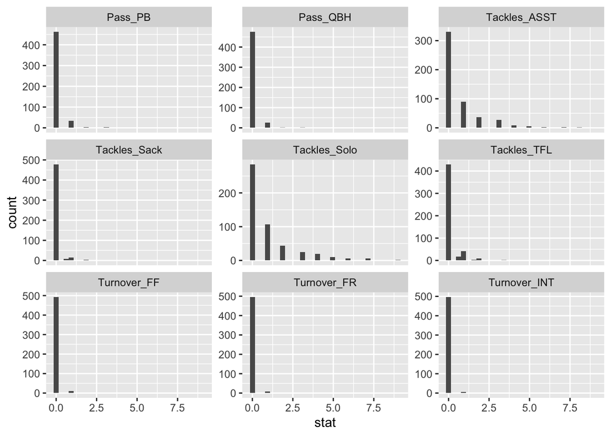

```r
defCleanLong<-defClean%>%
  pivot_longer(Tackles_Solo:Pass_PB, names_to="type", values_to='stat')

ggplot(defCleanLong, aes(x=stat))+geom_histogram()+facet_wrap(~type, scales='free_y')
```

What defensive skills are rare? It appears that Turnovers_Int, Turnover_FF, and Turnover_FR are the rareset defensive skills. This makes sense because in football, it is hard for the defense team to create turnovers.

Did ISU have better defense against Iowa or Notre Dame? Answer this question by creating a scatterplot with x- and y-axes being the number of solo tackles (of each player). A large number of solo tackles is an indicator of good defense.

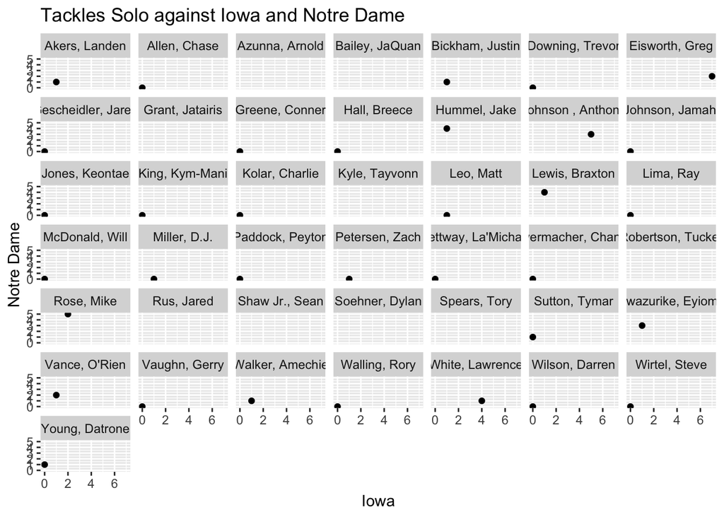

```r
data<-defCleanLong%>%
  filter(Opponent %in% c('Iowa','Notre Dame') & type=='Tackles_Solo')


wide<-data%>%
  pivot_wider(names_from='Opponent',values_from='stat')


ggplot(wide, aes(x=Iowa, y=`Notre Dame`))+geom_point()+ggtitle("Tackles Solo against Iowa and Notre Dame")+facet_wrap(~Name)
```

It seems that in general, the defense was better against Notre Dame. This is because they had more tackles indiviually against Notre Dame.

4. Separate the Hometown column into two columns, namely the city and the state. Print the first few rows of these two columns. (Hint: look at the sep= argument of separate)

```r
bioClean<-bioClean%>%
  separate(Hometown, into=c('City','State'), sep=',')

bioClean%>%
  select(City,State)%>%
  head()
```

```
## # A tibble: 6 x 2
##   City          State
##   <chr>         <chr>
## 1 Cedar Rapids  " Iowa"
## 2 Nixa          " Mo."
## 3 Seffner       " Fla."
## 4 Naperville    " Ill."
## 5 Grand Prairie " Texas"
## 6 Clarksdale    " Miss."
```

5. How many players are there from each state?

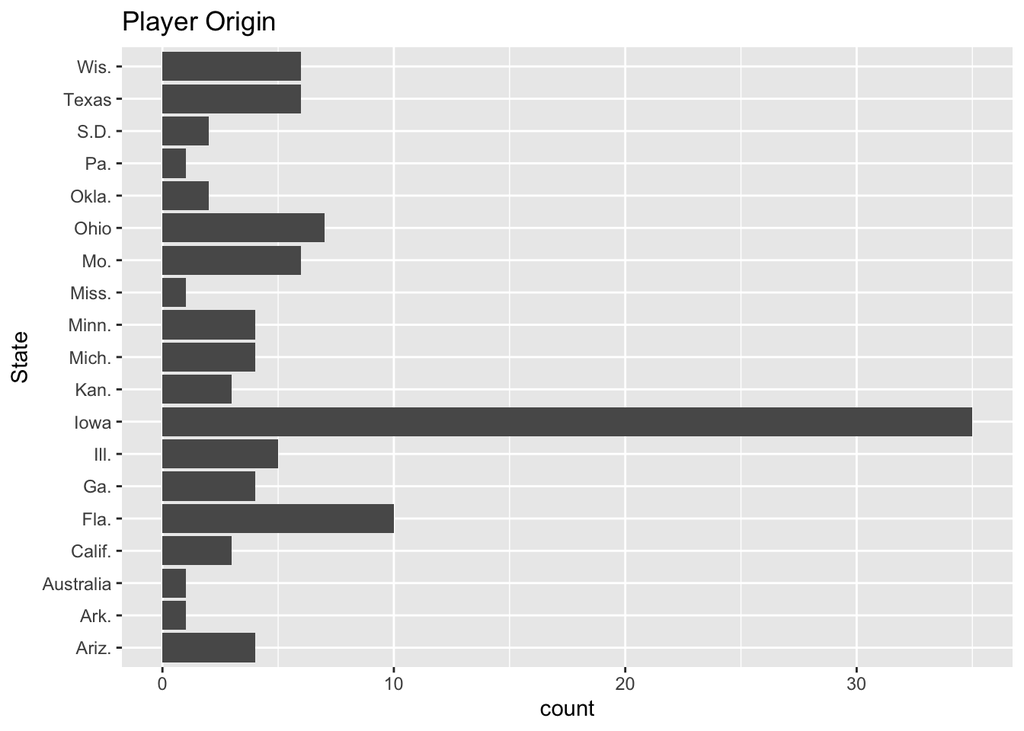

```r
ggplot(bioClean, aes(x=State))+geom_bar()+ggtitle("Player Origin")+coord_flip()
```

Part three: Joining data frames

1. Find which states do the ISU defensive and offensive players come from. Create an appropriate summary.

```r
playerState<-bioClean%>%
  select(Name,State)

originDef<-playerState%>%
  semi_join(defClean, by="Name")
originOff<-playerState%>%
  semi_join(offClean, by="Name")
```

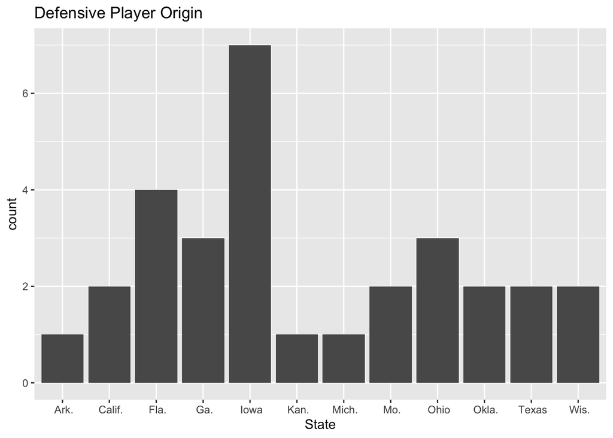

```r
ggplot(originDef, aes(x=State))+geom_bar()+ggtitle("Defensive Player Origin")
```

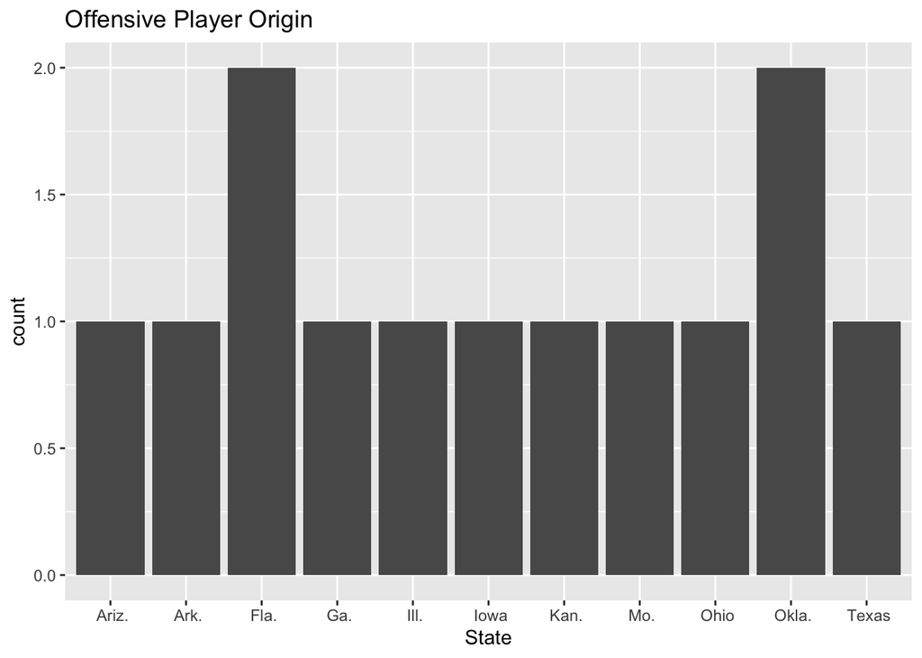

```r
ggplot(originOff, aes(x=State))+geom_bar()+ggtitle("Offensive Player Origin")
```

2. How does the performance of quarterback Brock Purdy relate to the performance of the ISU team?

```r
all<-defClean%>%
  full_join(offClean, by="Name")
all$performance<-all$Passing_YDS+all$Rushing_YDS+all$Tackles_Solo

all%>%
  select(Name, performance)%>%
  filter(Name=='Purdy, Brock')
```

```
## # A tibble: 13 x 2
##    Name         performance
##    <chr>              <dbl>
##  1 Purdy, Brock          NA
##  2 Purdy, Brock          NA
##  3 Purdy, Brock          NA
##  4 Purdy, Brock          NA
##  5 Purdy, Brock          NA
##  6 Purdy, Brock          NA
##  7 Purdy, Brock          NA
##  8 Purdy, Brock          NA
##  9 Purdy, Brock          NA
## 10 Purdy, Brock          NA
## 11 Purdy, Brock          NA
## 12 Purdy, Brock          NA
## 13 Purdy, Brock          NA
```

```r
head(all)
```

```
## # A tibble: 6 x 23
##   Name  Opponent.x Tackles_Solo Tackles_ASST Tackles_TFL Tackles_Sack
##   <chr> <fct>             <dbl>        <dbl>       <dbl>        <dbl>
## 1 Whit… UNI                   4            4           0            0
## 2 Whit… Iowa                  4            7           0            0
## 3 Whit… ULM                   3            5           0            0
## 4 Whit… Baylor                4            2           0            0
## 5 Whit… TCU                   3            2           1            0
## 6 Whit… West Virg…            1            1           0            0
## # … with 17 more variables: Turnover_FF <dbl>, Turnover_FR <dbl>,
## #   Turnover_INT <dbl>, Pass_QBH <dbl>, Pass_PB <dbl>, Opponent.y <fct>,
## #   Rushing_ATT <dbl>, Rushing_YDS <dbl>, Rushing_TD <dbl>,
## #   Receiving_REC <dbl>, Receiving_YDS <dbl>, Receiving_TD <dbl>,
## #   `Passing_CMP-ATT` <dbl>, Passing_YDS <dbl>, Passing_TD <dbl>,
## #   Passing_INT <dbl>, performance <dbl>
```

I was not able to find a way to compare Brock Purdy’s Stats to the rest of the team, but I was able to combine the two sheets through full join which kept all the stats in both data frames. I apologize.

3.Which ISU player(s) made big progress over the last year?

```r
def2018 <- read_excel('cyclonesFootball2018.xlsx', sheet='Defensive')
off2018 <- read_excel('cyclonesFootball2018.xlsx', sheet='Offensive')


defClean2018<-def2018%>%
  mutate(Opponent=factor(Opponent_Opponent))%>%
  mutate(Name=factor(Name))%>%
  mutate(Tackles_Solo=as.numeric(Tackles_Solo))%>%
  mutate(Tackles_ASST=as.numeric(Tackles_ASST))%>%
  mutate(Tackles_TFL=as.numeric(Tackles_TFL))%>%
  mutate(Tackles_Sack=as.numeric(Tackles_Sack))%>%
  mutate(Turnover_FF=as.numeric(Turnover_FF))%>%
  mutate(Turnover_FR=as.numeric(Turnover_FR))%>%
  mutate(Turnover_INT=as.numeric(Turnover_INT))%>%
  mutate(Pass_QBH=as.numeric(Pass_QBH))%>%
  mutate(Pass_PB=as.numeric(Pass_PB))%>%
  select(-Opponent_Opponent)

offClean2018<-off2018%>%
  mutate(Opponent=factor(Opponent_Opponent))%>%
  mutate(Name=factor(Name))%>%
  mutate(Rushing_ATT=as.numeric(Rushing_ATT))%>%
  mutate(Rushing_YDS=as.numeric(Rushing_YDS))%>%
  mutate(Rushing_TD=as.numeric(Rushing_TD))%>%
  mutate(Receiving_REC=as.numeric(Receiving_REC))%>%
  mutate(Receiving_YDS=as.numeric(Receiving_YDS))%>%
  mutate(Receiving_TD=as.numeric(Receiving_TD))%>%
  mutate(`Passing_CMP-ATT`=as.numeric(`Passing_CMP-ATT`))%>%
  mutate(Passing_YDS=as.numeric(Passing_YDS))%>%
  mutate(Passing_TD=as.numeric(Passing_TD))%>%
  mutate(Passing_INT=as.numeric(Passing_INT))%>%
  select(-Opponent_Opponent)
twoYrsDef<-defClean%>%
  left_join(defClean2018, by="Name")
twoYrsOff<-offClean%>%
  left_join(offClean2018, by="Name")
```

Since I struggled with the last question, I also was not sure of how to copare statistics here. However, looking a a few players individually, it appears Brock Purdy has gotten better on offense and Mike Rose has worse stats on defense.